# Opioid Crisis Analysis | Title Pending

## Part 2: Contrary to popular belief, the opioid crisis might not be a rural problem.

Although the opioid crisis is often thought of as a rural problem, the more remote counties were not as heavily hargeted with pill shipments as the more mid-range counties.

The Census Bureau and the USDA split all the U.S. counties into nine categories, 1 being the most urban, 9 being the least. Here’s a breakdown of their grouping system:

1. Metro - Counties in metro areas of 1 million population or more
2. Metro - Counties in metro areas of 250,000 to 1 million population
3. Metro - Counties in metro areas of fewer than 250,000 population
4. **Nonmetro - Urban population of 20,000 or more, adjacent to a metro area**
5. **Nonmetro - Urban population of 20,000 or more, not adjacent to a metro area**
6. **Nonmetro - Urban population of 2,500 to 19,999, adjacent to a metro area**
7. **Nonmetro - Urban population of 2,500 to 19,999, not adjacent to a metro area**
8. Nonmetro - Completely rural or less than 2,500 urban population, adjacent to a metro area
9. Nonmetro - Completely rural or less than 2,500 urban population, not adjacent to a metro area

The counties categorized as 4, 5, 6 and 7, nonmetro areas with urban populations, had the most signifigant positive relationships with the rate of opioid pills per person.

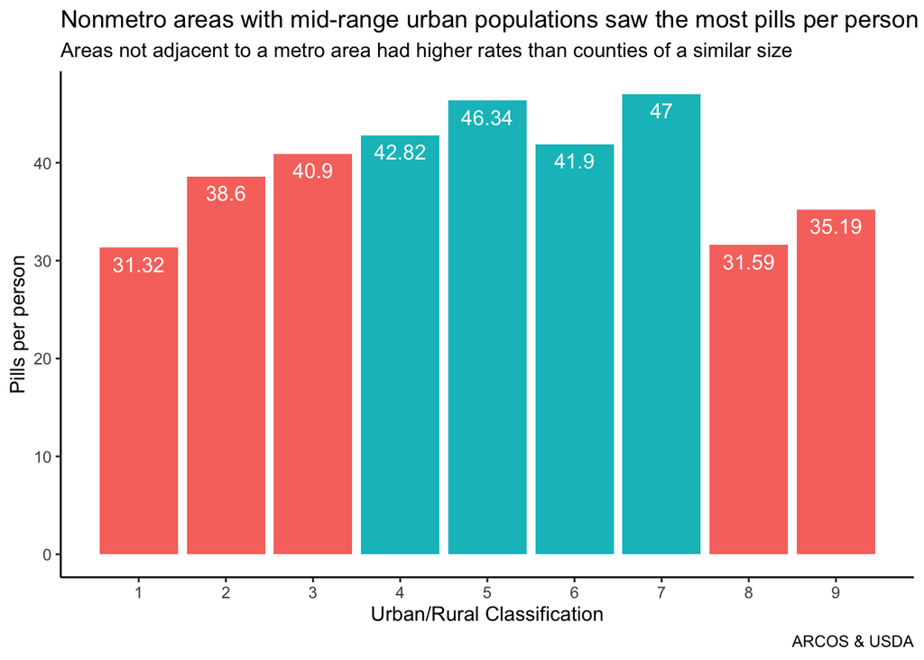

```r
ggplot(rural_urban_condensed) +
  geom_bar(stat="identity", aes(x=RUCC_2013, y=Pills_per_person, fill=color)) +
  guides(fill=FALSE) +
  geom_text(aes(x=RUCC_2013, y=Pills_per_person, label=Pills_per_person), vjust=1.6, color="white", size=4)+
  labs(x="Urban/Rural Classification", y="Pills per person", title="Nonmetro areas with mid-range urban populations saw the most pills per person", subtitle = "Areas not adjacent to a metro area had higher rates than counties of a similar size", caption = "ARCOS & USDA") +
  theme(axis.text.x = element_text(angle = 45, hjust = 1))+
  scale_y_continuous(labels = comma)+
  theme_classic()+
  scale_x_continuous(breaks = c(1,2,3,4,5,6,7,8,9))
```

The relationships between rural/urban classifications and pills per person were extremely signifigant, especially that of groups 5 and 7. Comparing the signifigance of groups with the same population size, it’s clear that proximity to a metro area is a predictor of the prevalence of opioid pills received.

```r
first_lm <- lm(Pills_per_person ~ RUCC_2013, data=big_data)
summary(first_lm)
```

```
##
## Call:
## lm(formula = Pills_per_person ~ RUCC_2013, data = big_data)
##
## Residuals:
##     Min      1Q  Median      3Q     Max
## -42.229 -13.989  -3.818   9.534 204.793
##
## Coefficients:
##             Estimate Std. Error t value Pr(>|t|)
## (Intercept)   35.129      1.083  32.437  < 2e-16 ***
## RUCC_20132     3.282      1.569   2.092 0.036496 *
## RUCC_20133     2.077      1.601   1.297 0.194664
## RUCC_20134     6.987      1.849   3.779 0.000161 ***
## RUCC_20135    10.343      2.515   4.113 4.01e-05 ***
## RUCC_20136     5.312      1.408   3.772 0.000165 ***
## RUCC_20137     7.113      1.509   4.713 2.55e-06 ***
## RUCC_20138    -6.804      1.876  -3.627 0.000291 ***
## RUCC_20139    -5.957      1.592  -3.742 0.000186 ***
## ---
## Signif. codes:  0 '***' 0.001 '**' 0.01 '*' 0.05 '.' 0.1 ' ' 1
##
## Residual standard error: 21.77 on 2971 degrees of freedom
##   (24 observations deleted due to missingness)
## Multiple R-squared:  0.04659,    Adjusted R-squared:  0.04402
## F-statistic: 18.15 on 8 and 2971 DF,  p-value: < 2.2e-16
```

## Part 3: Who was targetted?

Second point: here are the groups who were targeted by this trend:

```r
clean_lm <- lm(Pills_per_person ~ avg_expectancy+avg_unemployment+percent_white+avg_use+avg_use_male+avg_use_female, data=big_data)
summary(clean_lm)
```

```
##
## Call:
## lm(formula = Pills_per_person ~ avg_expectancy + avg_unemployment +
##     percent_white + avg_use + avg_use_male + avg_use_female,
##     data = big_data)
##
## Residuals:
##     Min      1Q  Median      3Q     Max
## -33.990  -7.846  -2.026   5.533 201.382
##
## Coefficients:
##                  Estimate Std. Error t value Pr(>|t|)
## (Intercept)      500.6167    29.6947  16.859  < 2e-16 ***
## avg_expectancy    -6.3795     0.3806 -16.762  < 2e-16 ***
## avg_unemployment   0.7737     0.3060   2.529 0.011666 *
## percent_white     42.8791     4.2894   9.996  < 2e-16 ***
## avg_use           15.2071     2.3707   6.415 2.54e-10 ***
## avg_use_male     -17.3223     2.8469  -6.085 1.89e-09 ***
## avg_use_female     2.6289     0.6827   3.851 0.000128 ***
## ---
## Signif. codes:  0 '***' 0.001 '**' 0.01 '*' 0.05 '.' 0.1 ' ' 1
##
## Residual standard error: 14.87 on 725 degrees of freedom
##   (2272 observations deleted due to missingness)
## Multiple R-squared:  0.3432, Adjusted R-squared:  0.3377
## F-statistic: 63.13 on 6 and 725 DF,  p-value: < 2.2e-16
```

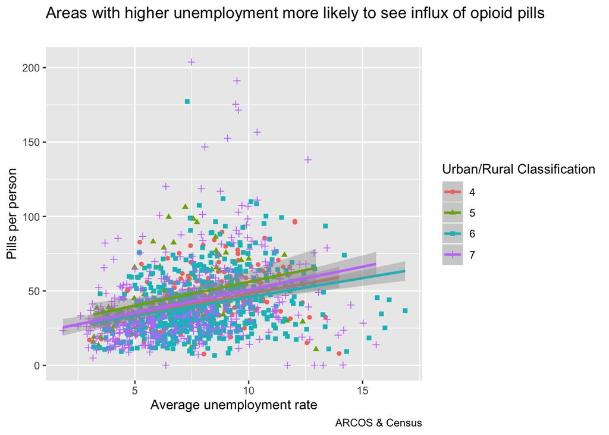

```r
big_data_focused <- big_data %>%
  filter(str_detect(RUCC_2013, "4|5|6|7"))

ggplot(big_data_focused, aes(x=avg_unemployment, y=Pills_per_person, shape=RUCC_2013, color=RUCC_2013)) +
  geom_point() +
  labs(x="Average unemployment rate", y="Pills per person", title="Areas with higher unemployment more likely to see influx of opioid pills", subtitle = "", caption = "ARCOS & Census", color="Urban/Rural Classification", shape="Urban/Rural Classification") +
  geom_smooth(method=lm)
```

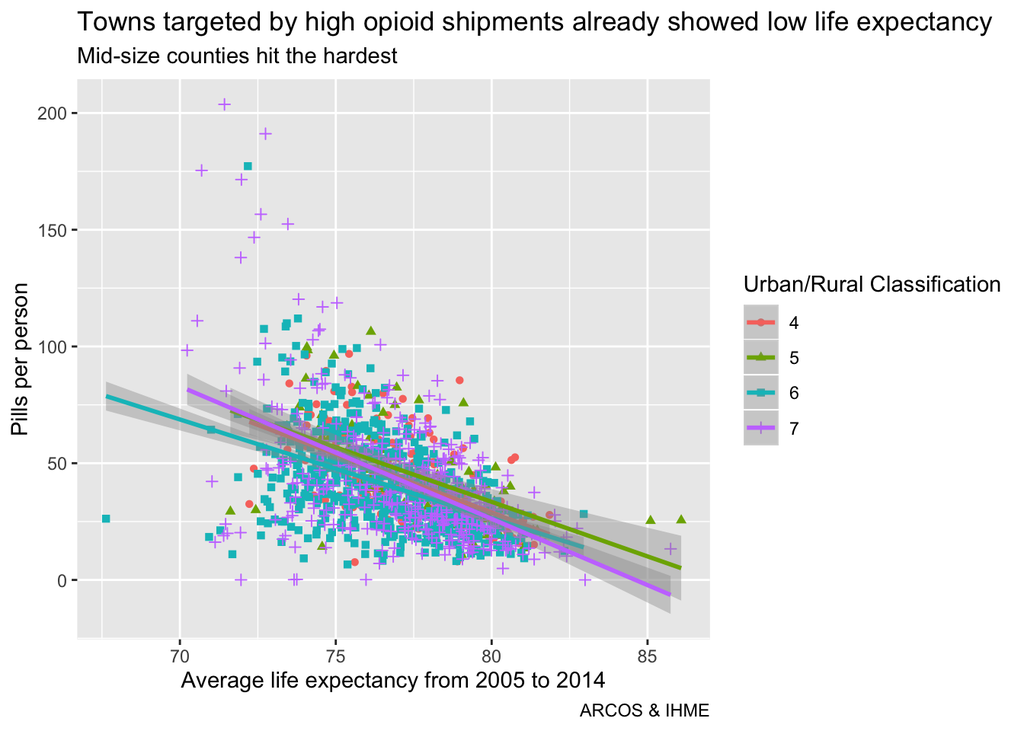

```r
ggplot(big_data_focused, aes(x=avg_expectancy, y=Pills_per_person, shape=RUCC_2013, color=RUCC_2013)) +
  geom_point() +
  labs(x="Average life expectancy from 2005 to 2014", y="Pills per person", title="Towns targeted by high opioid shipments already showed low life expectancy", subtitle = "Mid-size counties hit the hardest", caption = "ARCOS & IHME", color="Urban/Rural Classification", shape="Urban/Rural Classification") +
  geom_smooth(method=lm)
```

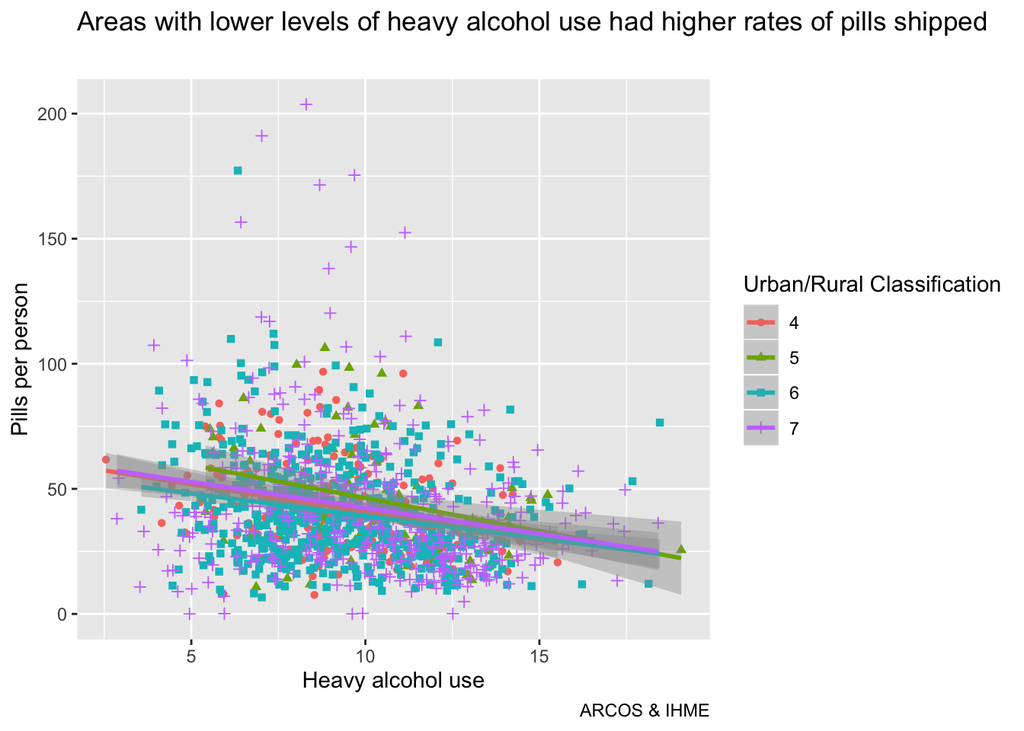

```r
ggplot(big_data_focused, aes(x=avg_use, y=Pills_per_person, shape=RUCC_2013, color=RUCC_2013)) +
  geom_point() +
  labs(x="Heavy alcohol use", y="Pills per person", title="Areas with lower levels of heavy alcohol use had higher rates of pills shipped", subtitle = "", caption = "ARCOS & IHME", color="Urban/Rural Classification", shape="Urban/Rural Classification") +
  geom_smooth(method=lm)
```